This notebook on Subset Selection is a Python adaptation of p. 244-247 of "Introduction to Statistical Learning with Applications in R" by Gareth James, Daniela Witten, Trevor Hastie and Robert Tibshirani. Adapted by R. Jordan Crouser at Smith College for SDS293: Machine Learning (Spring 2016). Github: https://github.com/JWarmenhoven/ISLR-python

```python
%matplotlib inline
import pandas as pd
import numpy as np
import itertools
import time
import statsmodels.api as sm
import matplotlib.pyplot as plt
import seaborn as sn
```

# Best Subset Selection

```python
df_no0 = pd.read_feather('../data/variables/vars_construction-industry_log.feather')
df_no0 = df_no0[df_no0.log_kgReceived > 0]
df_no0 = df_no0[['log_kgReceived', 'log_kgReceived_tot', 'log_kgProcessed_tot', 'log_kgProduced_tot',
       'log_kgReceived_tot_lag_wd4', 'log_kgReceived_tot_lag_wd10', 'log_kgReceived_tot_lag_wd30',
       'log_kgProcessed_tot_lag_wd4', 'log_kgProcessed_tot_lag_wd10', 'log_kgProcessed_tot_lag_wd30',
       'log_kgProduced_tot_lag_wd4', 'log_kgProduced_tot_lag_wd10', 'log_kgProduced_tot_lag_wd30', 'log_kgReceived_0-4km',
       'log_kgReceived_4-10km', 'log_kgReceived_10-30km', 'log_kgReceived_30-50km', 'log_kgReceived_>50km']]
print(df_no0.shape)
df_no0.head()
```

```
(809, 18)
```

|  | log_kgReceived | log_kgReceived_tot | log_kgProcessed_tot | log_kgProduced_tot | log_kgReceived_tot_lag_wd4 | log_kgReceived_tot_lag_wd10 | log_kgReceived_tot_lag_wd30 | log_kgProcessed_tot_lag_wd4 | log_kgProcessed_tot_lag_wd10 | log_kgProcessed_tot_lag_wd30 | log_kgProduced_tot_lag_wd4 | log_kgProduced_tot_lag_wd10 | log_kgProduced_tot_lag_wd30 | log_kgReceived_0-4km | log_kgReceived_4-10km | log_kgReceived_10-30km | log_kgReceived_30-50km | log_kgReceived_>50km |
| --- | --- | --- | --- | --- | --- | --- | --- | --- | --- | --- | --- | --- | --- | --- | --- | --- | --- | --- |
| 3 | 4.896747 | 4.896747 | 0.000000 | 7.446230 | 6.426645 | 6.527730 | 6.046970 | 7.792774 | 7.599487 | 7.271174 | 7.212301 | 7.174784 | 6.840929 | 0.000000 | 0.0 | 4.595717 | 4.595717 | 0.000000 |
| 8 | 6.018904 | 0.000000 | 0.000000 | 7.728221 | 3.430559 | 5.960433 | 6.050166 | 3.841638 | 7.267503 | 7.277497 | 7.178870 | 7.121275 | 6.846951 | 0.000000 | 0.0 | 6.018904 | 0.000000 | 0.000000 |
| 24 | 5.914354 | 5.914354 | 8.884565 | 7.712057 | 7.015411 | 6.561543 | 6.054558 | 8.118881 | 7.642683 | 7.247635 | 7.371613 | 7.167797 | 6.853514 | 5.914354 | 0.0 | 0.000000 | 0.000000 | 0.000000 |
| 25 | 5.991098 | 0.000000 | 8.758823 | 7.052236 | 7.218693 | 6.552845 | 6.061423 | 8.170202 | 7.651823 | 7.257235 | 7.379515 | 7.178486 | 6.856771 | 0.000000 | 0.0 | 5.775057 | 0.000000 | 5.584297 |
| 28 | 4.685383 | 8.009026 | 9.100752 | 7.872589 | 7.186458 | 6.515644 | 5.946601 | 8.363726 | 7.769913 | 7.226562 | 7.416456 | 7.141483 | 6.865508 | 0.000000 | 0.0 | 0.000000 | 0.000000 | 4.685383 |

```python
# create X and y variables
y = df_no0.log_kgReceived
X = df_no0.drop('log_kgReceived', axis=1)
```

In the cell below, we write the `processSubset` function that:

- takes a set of explanatory variables (feature_set)
- creates a linear regression model using this exVar set
- calculates the RSS for the model created (RSS = residual sum of squares, which measures the amount of variance in a data set that is not explained by a regression model itself)

```python
def processSubset(feature_set):
    # Fit model on feature_set and calculate RSS
    model = sm.OLS(y,X[list(feature_set)])
    regr = model.fit()
    RSS = ((regr.predict(X[list(feature_set)]) - y) ** 2).sum()
    return {"model":regr, "RSS":RSS, 'exVars':feature_set}
```

In the cell below, we write the `getBest` function that:

- takes in the number of explanatory variables we would like to compute (k)
- creates a list of all possible combinations of exVars for that number (e.g. k=1 creates 17 models, k=2 creates 136 models, k=3 creates 680 models...etc)
- creates a model for each of the possible combinations and calculates its RSS using the `processSubset` function (that we wrote in the cell above)
- picks the model with the lowest RSS
- returns a `dataframe` containing the best model that we generated for that number of explanatory variables, along with some extra information about the model.

```python
def getBest(k):

    tic = time.time()

    results = []

    for combo in itertools.combinations(X.columns, k):
        results.append(processSubset(combo))

    # Wrap everything up in a nice dataframe
    models = pd.DataFrame(results)

    # Choose the model with the lowest RSS
    best_model = models.loc[models['RSS'].argmin()]

    toc = time.time()
    print("Processed", models.shape[0], "models on", k, "predictors in", (toc-tic), "seconds.")

    # Return the best model, along with some other useful information about the model
    return best_model
```

Then, we place these models into one dataframe, along with their RSS values. Note that the smaller the RSS (residual sum of squares), the better. A low RSS means that the amount of variance in a data set that is not explained by a regression model itself is low.

```python
# Could take quite awhile to complete...
models_best = pd.DataFrame(columns=["RSS", "model", 'exVars'])

tic = time.time()

for i in range(1,10):
    models_best.loc[i] = getBest(i)

toc = time.time()
print("Total elapsed time:", (toc-tic), "seconds.")
```

```
Processed 17 models on 1 predictors in 0.0518190860748291 seconds.
Processed 136 models on 2 predictors in 0.309171199798584 seconds.
Processed 680 models on 3 predictors in 1.3723304271697998 seconds.
Processed 2380 models on 4 predictors in 7.940664052963257 seconds.
Processed 6188 models on 5 predictors in 18.50237512588501 seconds.
Processed 12376 models on 6 predictors in 47.90737056732178 seconds.
Processed 19448 models on 7 predictors in 84.0078558921814 seconds.
Processed 24310 models on 8 predictors in 113.10883975028992 seconds.
Processed 24310 models on 9 predictors in 118.10894846916199 seconds.
Total elapsed time: 395.35683488845825 seconds.
```

If we want to access the details of each model, we can get a full rundown of a single model using the `summary()` function. The cell below shows the best model for two explanatory variables. This output indicates that the best two-variable model contains only `log_kgReceived_tot` and `log_kgProduced_tot_lag_wd30`.

```python
print(models_best.loc[2, "model"].summary())
```

```
                                 OLS Regression Results
=======================================================================================
Dep. Variable:         log_kgReceived   R-squared (uncentered):                   0.965
Model:                            OLS   Adj. R-squared (uncentered):              0.965
Method:                 Least Squares   F-statistic:                          1.115e+04
Date:                Fri, 02 Jul 2021   Prob (F-statistic):                        0.00
Time:                        10:38:33   Log-Likelihood:                         -1126.3
No. Observations:                 809   AIC:                                      2257.
Df Residuals:                     807   BIC:                                      2266.
Df Model:                           2
Covariance Type:            nonrobust
===============================================================================================
                                  coef    std err          t      P>|t|      [0.025      0.975]
-----------------------------------------------------------------------------------------------
log_kgReceived_tot              0.2141      0.013     16.357      0.000       0.188       0.240
log_kgProduced_tot_lag_wd30     0.6207      0.010     62.752      0.000       0.601       0.640
==============================================================================
Omnibus:                        3.225   Durbin-Watson:                   1.791
Prob(Omnibus):                  0.199   Jarque-Bera (JB):                3.142
Skew:                          -0.152   Prob(JB):                        0.208
Kurtosis:                       3.031   Cond. No.                         3.75
==============================================================================

Notes:
[1] R² is computed without centering (uncentered) since the model does not contain a constant.
[2] Standard Errors assume that the covariance matrix of the errors is correctly specified.
```

The multiple linear regression models also produced many other useful statistics such as adjusted $R^2$, AIC, and BIC. We can examine these to try to select the best overall model.

```python
# add statistics to models_best df
models_best['rsquared_adj'] = models_best.model.map(lambda x: x.rsquared_adj)
models_best['aic'] = models_best.model.map(lambda x: x.aic)
models_best['bic'] = models_best.model.map(lambda x: x.bic)
models_best = models_best[['exVars', 'model', 'rsquared_adj', 'RSS', 'aic', 'bic']]
models_best
```

|  | exVars | model | rsquared_adj | RSS | aic | bic |
| --- | --- | --- | --- | --- | --- | --- |
| 1 | (log_kgProduced_tot_lag_wd30,) | <statsmodels.regression.linear_model.Regressio... | 0.953445 | 1021.179915 | 2486.270863 | 2490.966662 |
| 2 | (log_kgReceived_tot, log_kgProduced_tot_lag_wd30) | <statsmodels.regression.linear_model.Regressio... | 0.964994 | 766.909861 | 2256.617964 | 2266.009562 |
| 3 | (log_kgReceived_tot, log_kgProduced_tot_lag_wd... | <statsmodels.regression.linear_model.Regressio... | 0.968602 | 687.002991 | 2169.603187 | 2183.690584 |
| 4 | (log_kgReceived_tot, log_kgProduced_tot_lag_wd... | <statsmodels.regression.linear_model.Regressio... | 0.972024 | 611.376246 | 2077.252681 | 2096.035876 |
| 5 | (log_kgReceived_tot, log_kgProduced_tot_lag_wd... | <statsmodels.regression.linear_model.Regressio... | 0.973996 | 567.563824 | 2019.095968 | 2042.574963 |
| 6 | (log_kgReceived_tot, log_kgProcessed_tot_lag_w... | <statsmodels.regression.linear_model.Regressio... | 0.976156 | 519.786050 | 1949.955805 | 1978.130599 |
| 7 | (log_kgReceived_tot, log_kgProcessed_tot_lag_w... | <statsmodels.regression.linear_model.Regressio... | 0.978334 | 471.722083 | 1873.460737 | 1906.331330 |
| 8 | (log_kgReceived_tot, log_kgProcessed_tot_lag_w... | <statsmodels.regression.linear_model.Regressio... | 0.978410 | 469.473305 | 1871.594877 | 1909.161268 |
| 9 | (log_kgReceived_tot, log_kgReceived_tot_lag_wd... | <statsmodels.regression.linear_model.Regressio... | 0.978427 | 468.514546 | 1871.941046 | 1914.203236 |

In the cell below, we plot how the RSS, adjusted $R^2$, AIC, and BIC changes as we add more variables. This will help us decide which model to select as the best model overall. The red dots indicate the model which has the best condition for each statistic. For each statistic, the conditions are:

- the lower the RSS, the better
- the higher the adjusted $R^2$, the better
- the lower the AIC, the better
- the lower the BIC, the better

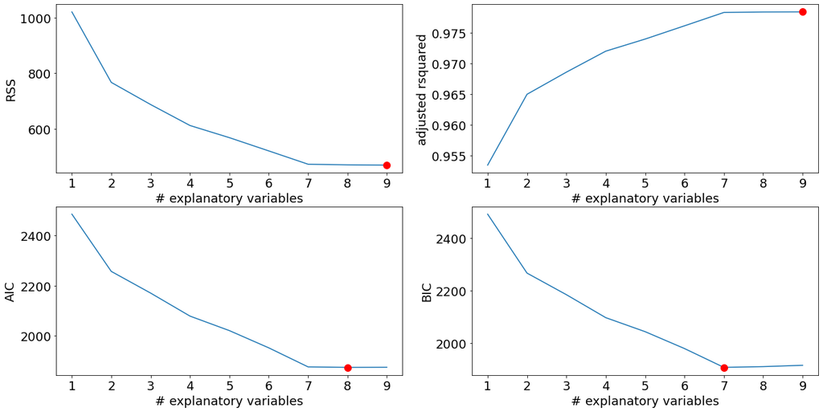

```python
plt.figure(figsize=(20,10))
plt.rcParams.update({'font.size': 18, 'lines.markersize': 10})

# Set up a 2x2 grid so we can look at 4 plots at once
plt.subplot(2, 2, 1)

# plot how RSS (residual sum of squares) reduces as we add more variables to the model
rss = models_best.RSS
plt.plot(rss)
plt.plot(rss.idxmin(), rss.min(), "or")
plt.xlabel('# explanatory variables')
plt.ylabel('RSS')

# plot r^2 adjusted
rsquared_adj = models_best.rsquared_adj
plt.subplot(2, 2, 2)
plt.plot(rsquared_adj)
plt.plot(rsquared_adj.idxmax(), rsquared_adj.max(), "or")
plt.xlabel('# explanatory variables')
plt.ylabel('adjusted rsquared')

# AIC
aic = models_best.aic
plt.subplot(2, 2, 3)
plt.plot(aic)
plt.plot(aic.idxmin(), aic.min(), "or")
plt.xlabel('# explanatory variables')
plt.ylabel('AIC')

# BIC
bic = models_best.bic
plt.subplot(2, 2, 4)
plt.plot(bic)
plt.plot(bic.idxmin(), bic.min(), "or")
plt.xlabel('# explanatory variables')
plt.ylabel('BIC')
```

Using the plots above, we can try to pick the best model with the least amount of explanatory variables. We want to minimize ex vars in order to avoid [overfitting](https://en.wikipedia.org/wiki/Overfitting) - the production of an analysis that corresponds too closely or exactly to a particular set of data, and may therefore fail to fit additional data or predict future observations reliably.

- if we look at adjusted r-squared, the more explanatory variables we add, the higher the r-squared gets, although it doesn't increase by much after 7 variables.
- if we look at AIC, the optimal number of ex variables is 8
- if we look at BIC, the optimal number of ex variables is 7

Looking at the plots above, we can tentatively say that the best model is produced by 7 explanatory variables, see the summary below.

```python
print(models_best.loc[7, "model"].summary())
```

```
                                 OLS Regression Results
=======================================================================================
Dep. Variable:         log_kgReceived   R-squared (uncentered):                   0.979
Model:                            OLS   Adj. R-squared (uncentered):              0.978
Method:                 Least Squares   F-statistic:                              5220.
Date:                Fri, 02 Jul 2021   Prob (F-statistic):                        0.00
Time:                        10:39:20   Log-Likelihood:                         -929.73
No. Observations:                 809   AIC:                                      1873.
Df Residuals:                     802   BIC:                                      1906.
Df Model:                           7
Covariance Type:            nonrobust
================================================================================================
                                   coef    std err          t      P>|t|      [0.025      0.975]
------------------------------------------------------------------------------------------------
log_kgReceived_tot               0.1044      0.011      9.128      0.000       0.082       0.127
log_kgProcessed_tot_lag_wd30     0.5035      0.009     58.366      0.000       0.487       0.520
log_kgReceived_0-4km             0.1279      0.014      9.040      0.000       0.100       0.156
log_kgReceived_4-10km            0.1313      0.012     10.834      0.000       0.108       0.155
log_kgReceived_10-30km           0.1696      0.011     15.256      0.000       0.148       0.191
log_kgReceived_30-50km           0.1412      0.013     10.872      0.000       0.116       0.167
log_kgReceived_>50km             0.1609      0.013     12.250      0.000       0.135       0.187
==============================================================================
Omnibus:                        8.020   Durbin-Watson:                   1.801
Prob(Omnibus):                  0.018   Jarque-Bera (JB):                7.935
Skew:                           0.235   Prob(JB):                       0.0189
Kurtosis:                       3.120   Cond. No.                         5.82
==============================================================================

Notes:
[1] R² is computed without centering (uncentered) since the model does not contain a constant.
[2] Standard Errors assume that the covariance matrix of the errors is correctly specified.
```

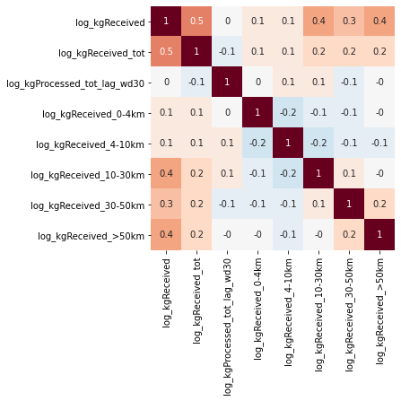

```python
# correlation matrix for the 7 best explanatory variables
exVars7 = ['log_kgReceived']
extend = list(models_best.loc[7, 'exVars'])
exVars7.extend(extend)
corr_exVars7 = df_no0[exVars7].corr().round(1)

# display
norm = plt.Normalize(-1,1)
fig, ax = plt.subplots(figsize=(5,5))
sn.heatmap(corr_exVars7, square=True, annot=True, ax=ax, cmap='RdBu_r', norm=norm, cbar=False)
plt.show()
```

## Forward stepwise selection

We can also use a similar approach to perform forward stepwise or backward stepwise selection, using a slight modification of the functions we defined above:

```python
def forward(predictors):

    # Pull out predictors we still need to process
    remaining_predictors = [p for p in X.columns if p not in predictors]

    tic = time.time()

    results = []

    for p in remaining_predictors:
        results.append(processSubset(predictors+[p]))

    # Wrap everything up in a nice dataframe
    models = pd.DataFrame(results)

    # Choose the model with the highest RSS
    best_model = models.loc[models['RSS'].argmin()]

    toc = time.time()
    print("Processed ", models.shape[0], "models on", len(predictors)+1, "predictors in", (toc-tic), "seconds.")

    # Return the best model, along with some other useful information about the model
    return best_model
```

```python
models_fwd = pd.DataFrame(columns=["RSS", "model"])

tic = time.time()
predictors = []

for i in range(1,len(X.columns)+1):
    models_fwd.loc[i] = forward(predictors)
    predictors = models_fwd.loc[i]["model"].model.exog_names

toc = time.time()
print("Total elapsed time:", (toc-tic), "seconds.")
```

```
Processed  17 models on 1 predictors in 0.08377528190612793 seconds.
Processed  16 models on 2 predictors in 0.03191494941711426 seconds.
Processed  15 models on 3 predictors in 0.037899017333984375 seconds.
Processed  14 models on 4 predictors in 0.031914710998535156 seconds.
Processed  13 models on 5 predictors in 0.02393651008605957 seconds.
Processed  12 models on 6 predictors in 0.03191328048706055 seconds.
Processed  11 models on 7 predictors in 0.021939992904663086 seconds.
Processed  10 models on 8 predictors in 0.03490614891052246 seconds.
Processed  9 models on 9 predictors in 0.02593064308166504 seconds.
Processed  8 models on 10 predictors in 0.02293872833251953 seconds.
Processed  7 models on 11 predictors in 0.016955852508544922 seconds.
Processed  6 models on 12 predictors in 0.014960527420043945 seconds.
Processed  5 models on 13 predictors in 0.021940946578979492 seconds.
Processed  4 models on 14 predictors in 0.009974002838134766 seconds.
Processed  3 models on 15 predictors in 0.009973526000976562 seconds.
Processed  2 models on 16 predictors in 0.016322612762451172 seconds.
Processed  1 models on 17 predictors in 0.004987001419067383 seconds.
Total elapsed time: 0.49005651473999023 seconds.
```

Phew! That's a lot better. Let's take a look:

```python
print(models_fwd.loc[1, "model"].summary())
print(models_fwd.loc[2, "model"].summary())
```

```
                                 OLS Regression Results
=======================================================================================
Dep. Variable:         log_kgReceived   R-squared (uncentered):                   0.954
Model:                            OLS   Adj. R-squared (uncentered):              0.953
Method:                 Least Squares   F-statistic:                          1.657e+04
Date:                Fri, 02 Jul 2021   Prob (F-statistic):                        0.00
Time:                        13:16:50   Log-Likelihood:                         -1242.1
No. Observations:                 809   AIC:                                      2486.
Df Residuals:                     808   BIC:                                      2491.
Df Model:                           1
Covariance Type:            nonrobust
===============================================================================================
                                  coef    std err          t      P>|t|      [0.025      0.975]
-----------------------------------------------------------------------------------------------
log_kgProduced_tot_lag_wd30     0.7591      0.006    128.722      0.000       0.748       0.771
==============================================================================
Omnibus:                       14.328   Durbin-Watson:                   1.764
Prob(Omnibus):                  0.001   Jarque-Bera (JB):                8.539
Skew:                          -0.052   Prob(JB):                       0.0140
Kurtosis:                       2.508   Cond. No.                         1.00
==============================================================================

Notes:
[1] R² is computed without centering (uncentered) since the model does not contain a constant.
[2] Standard Errors assume that the covariance matrix of the errors is correctly specified.
                                 OLS Regression Results
=======================================================================================
Dep. Variable:         log_kgReceived   R-squared (uncentered):                   0.965
Model:                            OLS   Adj. R-squared (uncentered):              0.965
Method:                 Least Squares   F-statistic:                          1.115e+04
Date:                Fri, 02 Jul 2021   Prob (F-statistic):                        0.00
Time:                        13:16:50   Log-Likelihood:                         -1126.3
No. Observations:                 809   AIC:                                      2257.
Df Residuals:                     807   BIC:                                      2266.
Df Model:                           2
Covariance Type:            nonrobust
===============================================================================================
                                  coef    std err          t      P>|t|      [0.025      0.975]
-----------------------------------------------------------------------------------------------
log_kgProduced_tot_lag_wd30     0.6207      0.010     62.752      0.000       0.601       0.640
log_kgReceived_tot              0.2141      0.013     16.357      0.000       0.188       0.240
==============================================================================
Omnibus:                        3.225   Durbin-Watson:                   1.791
Prob(Omnibus):                  0.199   Jarque-Bera (JB):                3.142
Skew:                          -0.152   Prob(JB):                        0.208
Kurtosis:                       3.031   Cond. No.                         3.75
==============================================================================

Notes:
[1] R² is computed without centering (uncentered) since the model does not contain a constant.
[2] Standard Errors assume that the covariance matrix of the errors is correctly specified.
```

```python
print(models_best.loc[6, "model"].summary())
print(models_fwd.loc[6, "model"].summary())
```

```
                                 OLS Regression Results
=======================================================================================
Dep. Variable:         log_kgReceived   R-squared (uncentered):                   0.976
Model:                            OLS   Adj. R-squared (uncentered):              0.976
Method:                 Least Squares   F-statistic:                              5521.
Date:                Fri, 02 Jul 2021   Prob (F-statistic):                        0.00
Time:                        13:16:58   Log-Likelihood:                         -968.98
No. Observations:                 809   AIC:                                      1950.
Df Residuals:                     803   BIC:                                      1978.
Df Model:                           6
Covariance Type:            nonrobust
================================================================================================
                                   coef    std err          t      P>|t|      [0.025      0.975]
------------------------------------------------------------------------------------------------
log_kgReceived_tot               0.1235      0.012     10.481      0.000       0.100       0.147
log_kgProcessed_tot_lag_wd30     0.5254      0.009     60.486      0.000       0.508       0.542
log_kgReceived_4-10km            0.1065      0.012      8.596      0.000       0.082       0.131
log_kgReceived_10-30km           0.1508      0.011     13.161      0.000       0.128       0.173
log_kgReceived_30-50km           0.1272      0.014      9.398      0.000       0.101       0.154
log_kgReceived_>50km             0.1530      0.014     11.129      0.000       0.126       0.180
==============================================================================
Omnibus:                       16.449   Durbin-Watson:                   1.809
Prob(Omnibus):                  0.000   Jarque-Bera (JB):               17.379
Skew:                           0.313   Prob(JB):                     0.000168
Kurtosis:                       3.353   Cond. No.                         5.10
==============================================================================

Notes:
[1] R² is computed without centering (uncentered) since the model does not contain a constant.
[2] Standard Errors assume that the covariance matrix of the errors is correctly specified.
                                 OLS Regression Results
=======================================================================================
Dep. Variable:         log_kgReceived   R-squared (uncentered):                   0.976
Model:                            OLS   Adj. R-squared (uncentered):              0.976
Method:                 Least Squares   F-statistic:                              5520.
Date:                Fri, 02 Jul 2021   Prob (F-statistic):                        0.00
Time:                        13:16:58   Log-Likelihood:                         -969.04
No. Observations:                 809   AIC:                                      1950.
Df Residuals:                     803   BIC:                                      1978.
Df Model:                           6
Covariance Type:            nonrobust
===============================================================================================
                                  coef    std err          t      P>|t|      [0.025      0.975]
-----------------------------------------------------------------------------------------------
log_kgProduced_tot_lag_wd30     0.5537      0.009     60.480      0.000       0.536       0.572
log_kgReceived_tot              0.1235      0.012     10.474      0.000       0.100       0.147
log_kgReceived_10-30km          0.1501      0.011     13.090      0.000       0.128       0.173
log_kgReceived_>50km            0.1535      0.014     11.163      0.000       0.127       0.180
log_kgReceived_30-50km          0.1246      0.014      9.201      0.000       0.098       0.151
log_kgReceived_4-10km           0.1063      0.012      8.583      0.000       0.082       0.131
==============================================================================
Omnibus:                       16.574   Durbin-Watson:                   1.801
Prob(Omnibus):                  0.000   Jarque-Bera (JB):               17.507
Skew:                           0.314   Prob(JB):                     0.000158
Kurtosis:                       3.353   Cond. No.                         4.96
==============================================================================

Notes:
[1] R² is computed without centering (uncentered) since the model does not contain a constant.
[2] Standard Errors assume that the covariance matrix of the errors is correctly specified.
```